# Basic data analysis using R Studio

Anoop Ambikan

## Introduction

This is a tutorial for performing basic data analysis using R studio. The tutorial cover basic statistical analysis including **various pair-wise statistical tests, clustering and few basic data visualizations**. Given below the topics covered in this tutorial.

1. PCA
2. UMAP
3. statistical tests for 2 groups
4. statistical tests for >2 groups
5. Box and violin plots
6. Bar graphs
7. Limma
8. Deseq2
9. Piano

## Package installation

A package is a bundle created using R programming language contains various functions perform specific tasks, demo data and user manuals. Developers create packages and make it publicly available for others to use. Developers submit the package in one of the repositories such as github, CRAN, Bioconductor or other private databases. We need to download source code for the package of interest and install locally to use it. Most of the packages can be installed by using the function **install.packages(“package name”)**. The package name is case sensitive, we need to give the exact package name. There are specific functions to install packages from bioconductor and github.

### Example installation 1

Open a new R script and save it as shown below.

[figure not shown]

Then check the package is already installed or not. It can be done by importing the package to rstudio using the command **library(packageName)**. Type the command and hit **Ctrl + Enter** . If not installed, it will say package not available

[figure not shown]

If not installed, search for the package to find if it is available in CRAN (look for the URL)

[figure not shown]

If it is available in CRAN type the below command and hit Ctrl + Enter

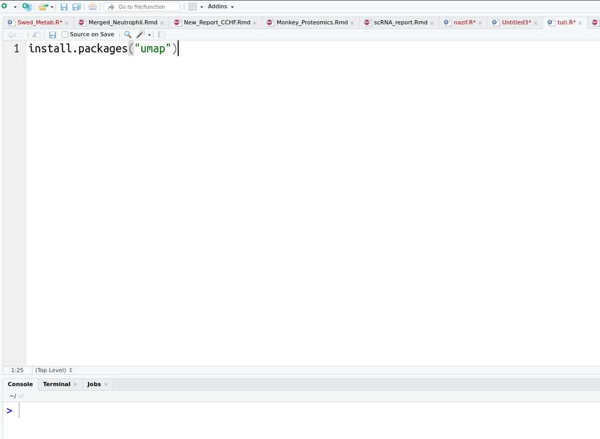

Check for successful installation. It will show “DONE” . Sometime it will show errors like, dependency packages are not available

[figure not shown]

Some package needs other package pre-installed. In that case install those first and then install the package of interest .

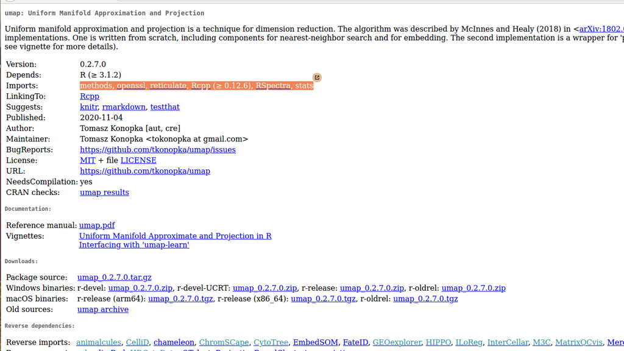

### Example installation 2

If the package is part of Bioconductor. Go to the bioconductor page.

[figure not shown]

copy the command for installation

[figure not shown]

We need to have pre-installed BiocManager package to install package from Bioconductor. So first install that

[figure not shown]

Execute command for installing PCA tools

[figure not shown]

## PCA

Firstly, for easy use, you can make a specific folder only for R and keep all the files inside. This can be done by the command **setwd() meaning set working directory**. Create a folder somewhere.

[figure not shown]

copy the path to the folder

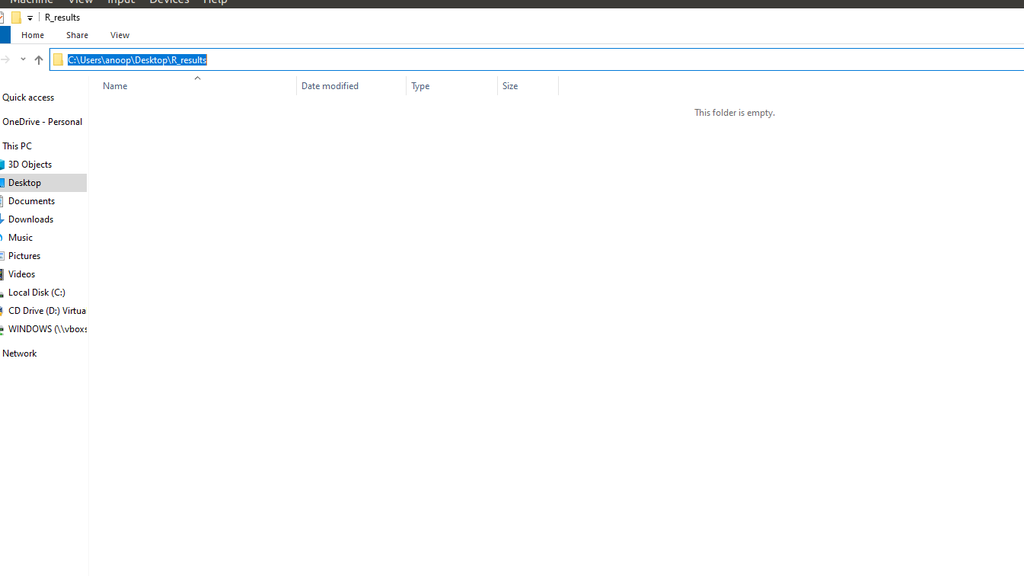

copy paste the commands one by one and hit Ctrl+ Enter to execute. You dont need to copy the message written after ‘#’. That is just comment. not part of command

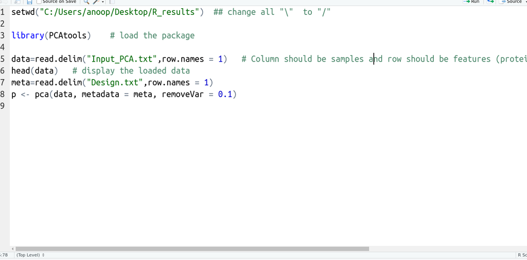

**When giving file path from Windows, you need to change all “\” to “/” . Once you set a folder as ur working directory it will remain like that till you close the R script. All the input files should be there in the folder and outputs will be written to there as well.**

```r
setwd("/home/anoop/Desktop/Tutorial/Analysis/")  ## Set working directory (folder). Give ur own folder.

library(PCAtools)    # load the package

data=read.delim("Input_PCA.txt",row.names = 1)   # Column should be samples and row should be features (protein etc)
head(data)   # display the loaded data
meta=read.delim("Design.txt",row.names = 1)
p <- pca(data, metadata = meta, removeVar = 0.1)
head(p$variance)   # variance captured by each PCs

p$rotated$Group=meta$Group
write.table(p$rotated,file="PCA_results.txt",sep="\t",col.names = NA,quote = FALSE)  # Download the PCs of all samples and add the metadata to draw nicer plot using ggplot2

Dat=read.delim("PCA_results.txt",row.names = 1)

pdf("PCA_plot.pdf")
ggplot(Dat, aes(x=PC1, y=PC2,color=Group)) + geom_point(size=3.7,aes(fill=Group),shape=21)+
  scale_color_manual(values=c(HC="#335b76",anti_pos="#9eb4cc",mild="#ccac00",severe="#cc8400"))+
  scale_fill_manual(values=c(HC="#48690E",anti_pos="#C6E2FF",mild="#ffd700",severe="#ffa500"))+
  labs(x="PC1, 47.4% variance",y="PC2, 7.73% variance")+theme(axis.title = element_text(size=10),legend.position = c(0.87, 0.11),plot.margin = margin(1,1,1,1, "cm"),
                                                              legend.title=element_text(size=9),legend.text=element_text(size=7),legend.key.size = unit(0.5, "cm"))+
  guides(shape = guide_legend(nrow = 1))
dev.off()

## You can play with plot margin to control figure size
## Below is the command for PCA plot with ellipse and centroid

dat=read.delim("PCA_results.txt",row.names = 1)
gg <- merge(dat,aggregate(cbind(mean.pc1=PC1,mean.pc2=PC2)~Group,dat,mean),by="Group")
pdf("PCA_plot_with_Ellipse.pdf")
ggplot(gg, aes(PC1,PC2,color=Group))+geom_point(size=3,aes(fill=Group))+
  geom_point(aes(x=mean.pc1,y=mean.pc2),size=5)+
  geom_segment(aes(x=mean.pc1, y=mean.pc2, xend=PC1, yend=PC2))+
  scale_color_manual(values=c(HC="#335b76",anti_pos="#9eb4cc",mild="#ccac00",severe="#cc8400"))+
  scale_fill_manual(values=c(HC="#48690E",anti_pos="#C6E2FF",mild="#ffd700",severe="#ffa500"))+
  labs(x="PC1, 47.4% variance",y="PC2, 7.73% variance")+theme(axis.title = element_text(size=10),legend.position = c(0.87, 0.11),plot.margin = margin(1,1,1,1, "cm"),
                                                              legend.title=element_text(size=9),legend.text=element_text(size=7),legend.key.size = unit(0.5, "cm"))+
  guides(shape = guide_legend(nrow = 1))+
  stat_ellipse(geom = "polygon",aes(fill = Group), alpha = 0.15,linetype = "dotted")
dev.off()
```

## UMAP

```r
library(umap)
data=read.delim("Input_PCA.txt",row.names = 1)
out.umap = umap(t(data))
UMAP_OUT=as.data.frame(out.umap$layout)
UMAP_OUT$Group=meta$Group

write.table(UMAP_OUT,file="UMAP_results.txt",sep="\t",col.names = NA,quote = FALSE)

Dat=read.delim("UMAP_results.txt",row.names = 1)

pdf("UMAP_plot.pdf")
ggplot(Dat, aes(x=V1, y=V2,color=Group)) + geom_point(size=3.7,aes(fill=Group),shape=21)+
  scale_color_manual(values=c(HC="#335b76",anti_pos="#9eb4cc",mild="#ccac00",severe="#cc8400"))+
  scale_fill_manual(values=c(HC="#48690E",anti_pos="#C6E2FF",mild="#ffd700",severe="#ffa500"))+
  labs(x="UMAP1",y="UMAP2")+theme(axis.title = element_text(size=10),legend.position = c(0.87, 0.11),plot.margin = margin(1,1,1,1, "cm"),
                                  legend.title=element_text(size=9),legend.text=element_text(size=7),legend.key.size = unit(0.5, "cm"))+
  guides(shape = guide_legend(nrow = 1))
dev.off()
```

## statistical tests for 2 groups

```r
library(tidyverse)
library(rstatix)

data=read.delim("Input_test.txt")  # Column should be features and row should be analysis groups
mydata <- data %>% as_tibble()

mydata.long <- mydata %>%
  pivot_longer(-Group, names_to = "variables", values_to = "value")

results <- mydata.long %>% group_by(variables) %>% t_test(value ~ Group) %>% adjust_pvalue(method = "BH") %>% add_significance()  ## t-test

write.table(as.data.frame(results),file="t_test_results.txt",sep = "\t",col.names = NA,quote = FALSE)

results <- mydata.long %>% group_by(variables) %>% wilcox_test(value ~ Group) %>% adjust_pvalue(method = "BH") %>% add_significance()  ## Mann-Whitney

write.table(as.data.frame(results),file="Mann_Whitney_results.txt",sep = "\t",col.names = NA,quote = FALSE)
```

## statistical tests for >2 groups

```r
library(tidyverse)
library(rstatix)

data=read.delim("Input_test.txt")  # Column should be features and row should be analysis groups
mydata <- data %>% as_tibble()

mydata.long <- mydata %>%
  pivot_longer(-Group, names_to = "variables", values_to = "value")

results <- mydata.long %>% group_by(variables) %>% anova_test(value ~ Group) %>% adjust_pvalue(method = "BH") %>% add_significance()  ## ANOVA

write.table(as.data.frame(results),file="Anova_results.txt",sep = "\t",col.names = NA,quote = FALSE)

results <- mydata.long %>% group_by(variables) %>% kruskal_test(value ~ Group) %>% adjust_pvalue(method = "BH") %>% add_significance()  ## kruskal-wallis rank sum test

write.table(as.data.frame(results),file="kruskal_test_results.txt",sep = "\t",col.names = NA,quote = FALSE)
```

## 5. Box and violin plots

```r
Data=read.delim("Input_test.txt",header = TRUE,check.names = FALSE)
head(Data)
Selected=Data %>% select(2:11)
Selected$Group=Data$Group
head(Selected)

library(reshape2)
library(ggpubr)
library(ggplot2)

M=melt(Selected,id.vars = "Group")

my_comparisons = list( c("HC", "mild"),c("HC", "severe"),c("mild", "severe"))
pdf("BoxPlot.pdf",width = 15,height = 12)
ggplot(M,aes(x=factor(Group,levels = unique(Group)),y=value,fill=Group,color=Group))+
  geom_boxplot(outlier.shape = NA)+
  facet_wrap(~ variable, ncol = 5,nrow = 2,scales ="free" )+
  geom_jitter(shape=16, size=1,color="black",position=position_jitter(0.05))+
  scale_color_manual(values=c(HC="#335b76",anti_pos="#9eb4cc",mild="#ccac00",severe="#cc8400"))+
  scale_fill_manual(values=c(HC="#48690E",anti_pos="#C6E2FF",mild="#ffd700",severe="#ffa500"))+
  theme_bw()+
  stat_compare_means(label = "p.format",comparisons = my_comparisons,method = "wilcox.test")+
  theme(axis.title.x = element_blank(),axis.title.y = element_blank(),legend.position ="right",panel.border = element_blank(),
        axis.ticks.x = element_blank(),axis.text.x = element_blank(),legend.title = element_blank(),legend.text = element_text(size = 15),
        plot.margin = margin(4,0.1,4,0.1, "cm"),strip.text.x = element_text(size = 12),
        axis.text.y = element_text(color="black",size=12),plot.title = element_text(hjust = 0.5,size = 15))+
  guides(color = guide_legend(ncol = 1),fill = guide_legend(ncol = 1))
dev.off()
```

```r
Data=read.delim("Input_test.txt",header = TRUE,check.names = FALSE)
head(Data)
Selected=Data %>% select(2:11)
Selected$Group=Data$Group
head(Selected)

library(reshape2)
library(ggpubr)
library(ggplot2)

M=melt(Selected,id.vars = "Group")

my_comparisons = list( c("HC", "mild"),c("HC", "severe"),c("mild", "severe"))
pdf("ViolinPlot.pdf",width = 15,height = 12)
ggplot(M,aes(x=factor(Group,levels = unique(Group)),y=value,fill=Group,color=Group))+
  geom_violin()+
  facet_wrap(~ variable, ncol = 5,nrow = 2,scales ="free" )+
  geom_jitter(shape=16, size=1,color="black",position=position_jitter(0.05))+
  scale_color_manual(values=c(HC="#335b76",anti_pos="#9eb4cc",mild="#ccac00",severe="#cc8400"))+
  scale_fill_manual(values=c(HC="#48690E",anti_pos="#C6E2FF",mild="#ffd700",severe="#ffa500"))+
  theme_bw()+
  stat_compare_means(label = "p.format",comparisons = my_comparisons,method = "wilcox.test")+
  theme(axis.title.x = element_blank(),axis.title.y = element_blank(),legend.position ="right",panel.border = element_blank(),
        axis.ticks.x = element_blank(),axis.text.x = element_blank(),legend.title = element_blank(),legend.text = element_text(size = 15),
        plot.margin = margin(4,0.1,4,0.1, "cm"),strip.text.x = element_text(size = 12),
        axis.text.y = element_text(color="black",size=12),plot.title = element_text(hjust = 0.5,size = 15))+
  guides(color = guide_legend(ncol = 1),fill = guide_legend(ncol = 1))
dev.off()
```